# ML3_FinalProject

```python
%%HTML
<script src="require.js"></script>
```

```python
from IPython.display import HTML
HTML('''<script src="https://cdnjs.cloudflare.com/ajax/libs/jquery/2.0.3/jquery.min.js "></script><script>
code_show=true;
function code_toggle() {
if (code_show){
$('div.jp-CodeCell > div.jp-Cell-inputWrapper').hide();
} else {
$('div.jp-CodeCell > div.jp-Cell-inputWrapper').show();
}
code_show = !code_show
}
$( document ).ready(code_toggle);</script><form action="javascript:code_toggle()"><input type="submit" value="Toggle on/off for raw code"></form>
''')
```

```python
HOME_DIR = ''
```

[figure not shown]

```python
from IPython.display import display, Image, Markdown

Image(filename=HOME_DIR + 'images/Title.PNG', width=1080)
```

# ABSTRACT

The project aims to create a deep learning model that can take audio data and classify it based on the emotion presented by the speaker. This was done by taking an already fine-tuned Wav2Vec model and further fine-tuning it on a dataset more than 2x the original one. The datasets involved are RAVDESS, TESS, and CREMA-D, all open source audio datasets that were developed for this very purpose.

With the new fine-tuned model, the researchers were able to achieve an 85% test accuracy--wherein the original test accuracy with the original model was only around 60%. The project demonstrates the value of fine-tuning an existing state-of-the-art model on a larger dataset.

# INTRODUCTION

Emotion classification from audio is a critical task in areas such as human-computer interaction, sentiment analysis, and behavioral studies. The challenge lies in accurately identifying and categorizing emotions conveyed through speech, which can vary significantly across different speakers and contexts.

"Emotion is the cornerstone of human interactions. In fact, the manner in which something is said can convey just as much information as the words being spoken. Emotional cues in speech are conveyed through vocal inflections known as prosody. Key attributes of prosody include the relative pitch, duration, and intensity of the speech signal." <sup>[[1](https://engineering.jhu.edu/nsa/research/emotional-speech/#:~:text=Emotional%20cues%20in%20speech%20are,of%20which%20impact%20emotion%20perception)]</sup>

Audio features like mel spectrograms and MFCCs are instrumental in capturing these attributes. A mel spectrogram visualizes how the frequency content of speech varies over time, reflecting changes in pitch and intensity. MFCCs, on the other hand, summarize the timbral characteristics of the audio, which helps in capturing subtle variations in pitch and emotional tone. These features enable the effective analysis and classification of emotional cues in speech.

# PROBLEM STATEMENT AND MOTICATION

**How can we use audio data to classify emotions?**

The primary objective of this study is to explore effective methods for classifying emotions using audio data. The analysis compares traditional feature extraction techniques against modern deep learning-based audio embeddings, with a particular focus on the application of the Wav2Vec model. The goal is to determine which approach offers superior accuracy and reliability in emotion classification tasks.

Some practical use cases include:

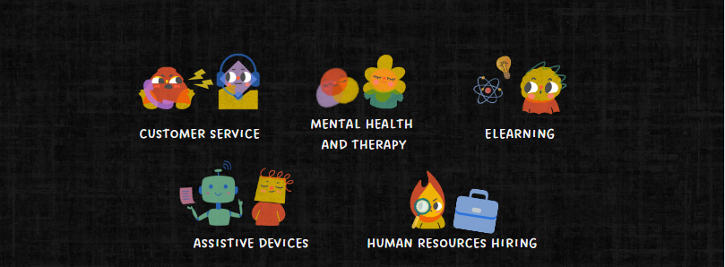

```python
Image(filename=HOME_DIR + 'images/Use Cases.PNG', width=1080)
```

1. **Customer Service**
   - Emotion classification to increase customer service performance--whether CCAI or human CS.
2. **Mental Health and Therapy**
   - SER can help therapists and mental health professionals monitor patient progress and emotional states during sessions. It may also assist in early detection of conditions like depression.
3. **Education and eLearning**
   - SER can provide insights into student engagement and comprehension levels in online learning environments. Teachers can use this data to adapt their teaching styles and provide more personalized learning experiences. This is instrumental in identifying whether the student is in a condition to learn or not.
4. **Automotive and Transportation**
   - In-car SER systems can detect driver fatigue, stress or distraction and provide alerts to prevent accidents. In an end-to-end ecosystem, It can also trigger adjustments to music, temperature or lighting to improve driver comfort and safety.
5. **Robotics and Assistive Devices**
   - Robots and assistive devices equipped with SER can better understand and respond to human emotions. This allows for more natural and empathetic interactions, especially for applications involving the elderly or disabled.
6. **Market Research and Advertising**
   - SER can analyze audience reactions to products, ads or entertainment content. This provides valuable insights into consumer preferences and emotional responses that can inform marketing strategies.
7. **Hiring and Employee Monitoring**
   - SER can be used to assess candidate suitability for customer-facing roles by evaluating their emotional responses during interviews. It can also monitor employee wellbeing and performance in high-stress jobs like call centers. While SER models have great potential, it's important to consider privacy concerns, bias mitigation and ethical implications when deploying them in real-world applications. Ongoing research aims to develop more robust, fair and user-centric SER systems to unlock the full benefits of this technology.

# METHODOLOGY

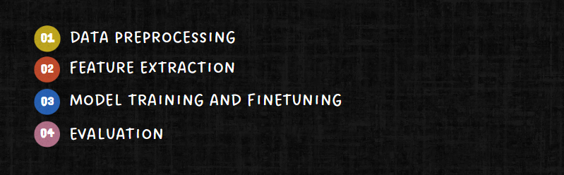

```python
Image(filename=HOME_DIR + 'images/Methodology.PNG', width=1080)
```

**1. Data Preprocessing**

- Prepare and organize the audio data by combining multiple datasets, ensuring that all labels and filepaths are accurate and consistent. Given the importance of pitch, duration, and intensity, avoid data augmentation that could distort these features.

**2. Feature Extraction**

- Convert raw audio into a form that models can use. Two approaches are explored:
  - *Traditional Features* - Techniques such as mel spectrograms, MFCCs, and pitch analysis are used to manually extract features that capture the characteristics of the audio signal.
  - *Audio Embeddings with Wav2Vec* - A modern approach that uses the Wav2Vec model to automatically learn and generate embeddings directly from the raw audio, capturing more nuanced aspects of the sound.

**3. Model Training and Finetuning**

- CLSTM (Convolutional LSTM) Model: Trained on traditional features, this model combines convolutional layers to capture local patterns with LSTM layers to handle the temporal dynamics of the audio.
- Pretrained Wav2Vec Model: This model uses embeddings from the Wav2Vec model and fine-tunes them on the specific task of emotion classification, leveraging pre-learned audio representations. Description

**4. Evaluation**

- Evaluate models based on their accuracy in classifying emotions, allowing for a direct comparison of the effectiveness of the CLSTM model versus the pretrained Wav2Vec model.

# SCOPE AND LIMITATION

- The study is limited to audio data and may not account for multimodal aspects of emotion classification.
- Results may vary depending on the quality and representativeness of the datasets used, especially since they are from actors and may not fully capture everyday speech nuances.
- The effectiveness of the Wav2Vec model and CLSTM model is evaluated solely based on emotion classification accuracy, which may not cover other relevant performance metrics or practical considerations in real-world applications.

# DEPENDENCIES

The dependencies for emotion classification from audio data include several key libraries. `librosa` is utilized for analyzing and extracting features from audio files. For model development, `keras` and `torch` are used for building and training neural networks. Pre-trained models from [🤗 Hugging Face](https://huggingface.co/) are also used in these deep learning tasks.

```
# DEPENDENCIES
!pip install git+https://github.com/huggingface/transformers.git
!pip install datasets
!pip install huggingface-hub
!pip install joblib
!pip install librosa
!pip install pyctcdecode
!pip install tokenizers
!pip install keras
!pip install tensorflow
!pip install torchsummary
```

```python
import pandas as pd
import numpy as np
import ast

from tqdm import tqdm
import json
import os
import zipfile

import librosa
import librosa.display
import seaborn as sns
import matplotlib.pyplot as plt

from sklearn.preprocessing import StandardScaler, OneHotEncoder, LabelEncoder
from sklearn.metrics import confusion_matrix, classification_report
from sklearn.model_selection import train_test_split

import IPython.display as ipd
from IPython.display import Audio

from keras.callbacks import ReduceLROnPlateau
from keras.models import Sequential, model_from_json
from keras.layers import Dense, Conv1D, MaxPooling1D, Flatten, Dropout, BatchNormalization, LSTM, GlobalAveragePooling1D, Layer, TimeDistributed
from keras.callbacks import ModelCheckpoint

import torch
import torch.nn as nn
import torch.nn.functional as F
from torchsummary import summary

from huggingface_hub import PyTorchModelHubMixin
from transformers import Wav2Vec2Config, Wav2Vec2Model
from transformers import Wav2Vec2FeatureExtractor, Wav2Vec2Processor

# Suppress warnings
import warnings
warnings.filterwarnings('ignore')
```

# DATASETS

The datasets used are open-source audio emotion classification datasets available online: RAVDESS, CREMA-D, and TESS. They consist of recordings with diverse emotional expressions and are publicly available for research and development purposes. The datasets are extracted from ZIP files and organized into specific directories for ease of use.

## Ryerson Audio-Visual Database of Emotional Speech and Song (RAVDESS) Dataset

The RAVDESS dataset provides 1440 audio files from 24 professional actors (12 female, 12 male) for emotion classification, with filenames encoded to include modality, vocal channel, emotion, emotional intensity, statement, repetition, and actor information.<sup>[[2](https://zenodo.org/records/1188976#.YFZuJ0j7SL8)][[3](https://datasets.activeloop.ai/docs/ml/datasets/ravdess-dataset/)][[4](https://www.kaggle.com/datasets/uwrfkaggler/ravdess-emotional-speech-audio/data)]</sup>

- Modality (01 = full-AV, 02 = video-only, 03 = audio-only).
- Vocal channel (01 = speech, 02 = song).
- Emotion (01 = neutral, 02 = calm, 03 = happy, 04 = sad, 05 = angry, 06 = fearful, 07 = disgust, 08 = surprised).
- Emotional intensity (01 = normal, 02 = strong). NOTE: There is no strong intensity for the 'neutral' emotion.
- Statement (01 = "Kids are talking by the door", 02 = "Dogs are sitting by the door").
- Repetition (01 = 1st repetition, 02 = 2nd repetition).
- Actor (01 to 24. Odd numbered actors are male, even numbered actors are female).

## Toronto Emotional Speech Set (TESS) Dataset

The TESS dataset provides 2800 audio files from 2 female actors for emotion classification, with filenames indicating the emotional content.<sup>[[5](https://tspace.library.utoronto.ca/handle/1807/24487)]</sup>

## Crowd Sourced Emotional Multimodal Actors Dataset (CREMA-D) Dataset

CREMA-D is a data set of 7,442 original clips from 91 actors. These clips were from 48 male and 43 female actors between the ages of 20 and 74 coming from a variety of races and ethnicities (African America, Asian, Caucasian, Hispanic, and Unspecified). Actors spoke from a selection of 12 sentences. The sentences were presented using one of six different emotions (Anger, Disgust, Fear, Happy, Neutral, and Sad) and four different emotion levels (Low, Medium, High, and Unspecified).<sup>[[6](https://www.kaggle.com/datasets/ejlok1/cremad)]</sup>

# DATA EXPLORATION

The data exploration involves analyzing the distribution of emotions in the combined dataset. A color-coded plot visualizes the count of each emotion.

```python
data_path = pd.read_csv(HOME_DIR + "data/data_path.csv")
```

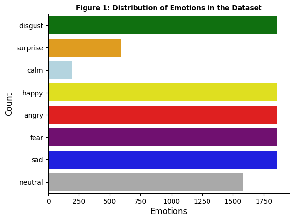

```python
emotion_colors = {
    'surprise': 'orange',    # orange
    'sad': 'blue',           # blue
    'calm': 'lightblue',     # lightblue
    'happy': 'yellow',       # yellow
    'disgust': 'green',      # green
    'fear': 'purple',        # purple
    'angry': 'red',          # red
    'neutral': 'darkgray'    # dark gray
}

plt.title('Figure 1: Distribution of Emotions in the Dataset', size=10, weight='bold')
sns.countplot(data_path.Emotions, palette=emotion_colors)
plt.ylabel('Count', size=12)
plt.xlabel('Emotions', size=12)
sns.despine(top=True, right=True, left=False, bottom=False)
plt.show()
```

The analysis reveals that `calm` occur too infrequently, leading to their removal from the dataset. Meanwhile, we retain `surprise` as it is an output of the pretrained model.

```python
# creating Dataframe using all the 4 dataframes we created so far.
data_path =  data_path[data_path.Emotions!='calm']
print(data_path.Emotions.value_counts())
```

```
disgust     1863
happy       1863
angry       1863
fear        1863
sad         1863
neutral     1583
surprise     592
Name: Emotions, dtype: int64
```

### Sample Audio

A sample audio is loaded and visualized using `librosa`. The waveform is displayed to provide a view of the audio signal's amplitude over time.

[interactive chart not shown]

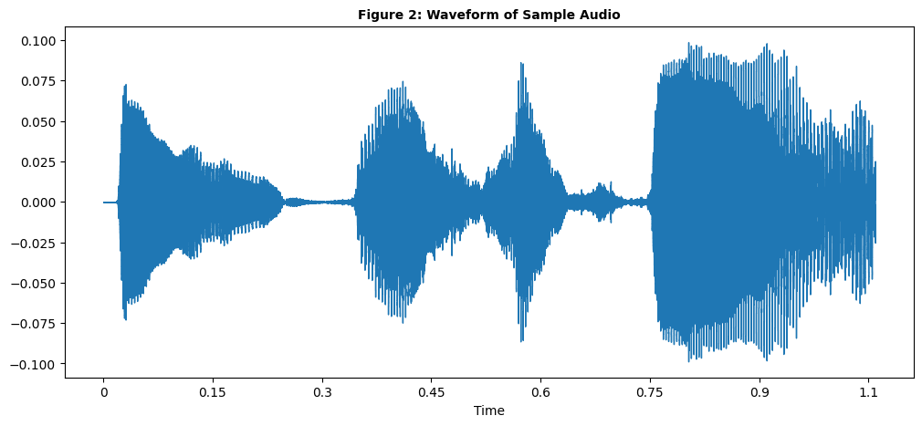

```python
sample_path = HOME_DIR + 'samples/sample_audio.mp3'
data,sr = librosa.load(sample_path)
plt.figure(figsize=(12, 5))
plt.title('Figure 2: Waveform of Sample Audio', size=10, weight='bold')
librosa.display.waveshow(y=data, sr=sr)
ipd.Audio(data,rate=sr)
```

A log-mel spectrogram converts the audio into a visual representation of its frequency content over time, highlighting different sound frequencies with color coding. This graph provides insight into the frequency content and how it changes, which relates to pitch and intensity—key attributes of prosody.

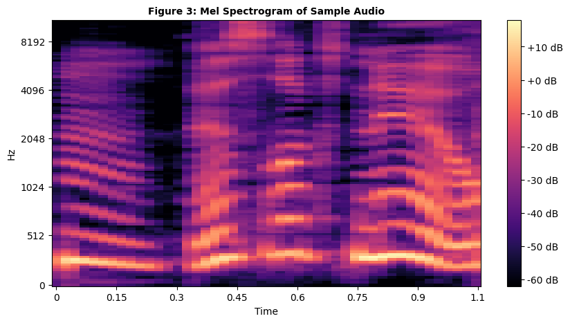

```python
plt.figure(figsize=(10, 5))
spectrogram = librosa.feature.melspectrogram(y=data, sr=sr, n_mels=128,fmax=8000)
log_spectrogram = librosa.power_to_db(spectrogram)
librosa.display.specshow(log_spectrogram, y_axis='mel', sr=sr, x_axis='time');
plt.title('Figure 3: Mel Spectrogram of Sample Audio', size=10, weight='bold')
plt.colorbar(format='%+2.0f dB')
plt.show()
```

The Mel-Frequency Cepstral Coefficients (MFCCs) captures the audio's timbral features and are visualized to show how these features vary over time in the sample audio. The MFCC visualization captures the timbral features of the audio, which can indicate variations in pitch and emotional tone.

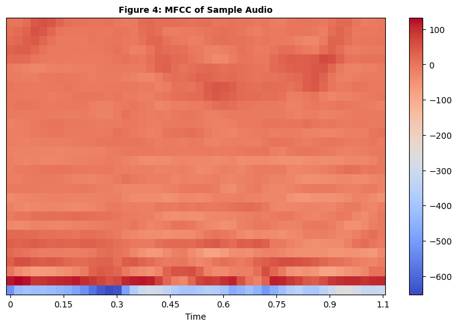

```python
mfcc = librosa.feature.mfcc(y=data, sr=sr, n_mfcc=30)

plt.figure(figsize=(10, 20))
plt.subplot(3,1,1)
librosa.display.specshow(mfcc, x_axis='time')
plt.title('Figure 4: MFCC of Sample Audio', size=10, weight='bold')
plt.colorbar()
plt.show()
```

# DATA PREPARATION

In the data preparation phase, the script loads and processes audio files from the dataset. For each entry in the dataset, it reads the audio file using librosa, normalizes the sample rate to 16,000 Hz, and stores the audio data along with its corresponding emotion label. This information is compiled into a list of dictionaries, which is then converted into a dataframe.

```
raw_data = []
for ind, row in data_path.iterrows():
  temp = {}
  audio = librosa.load(row['Path'], sr=16000)
  temp['audio'] = audio[0]
  temp['label'] = row['Emotions']
  raw_data.append(temp)

raw_df = pd.DataFrame(raw_data)
raw_df
```

```python
# Using random sample only of the generated data for demonstration purposes
raw_df = pd.read_csv(HOME_DIR + 'data/raw_df_samp.csv')
raw_df['audio'] = raw_df['audio'].apply(json.loads).apply(np.array)
```

```python
display(Markdown('**Table 1: Numerical Representation of Raw Audio with Labels**'))
raw_df.head()
```

**Table 1: Numerical Representation of Raw Audio with Labels**

|  | audio | label |
| --- | --- | --- |
| 0 | [9.941309690475464e-05, 0.00015194308070931584... | fear |
| 1 | [-1.2812488421332091e-06, 7.611568435095251e-0... | surprise |
| 2 | [2.1145342543604784e-05, 3.149499752908014e-05... | sad |
| 3 | [1.9020808394998312e-07, -3.2744537747930735e-... | surprise |
| 4 | [-2.4696433683857322e-05, -4.170120882918127e-... | disgust |

The emotion labels are converted into numerical values using a `LabelEncoder`. This transformation changes the categorical labels into integers, making the data ready for machine learning models. The updated dataframe now includes these numerical labels.

```python
le = LabelEncoder()
raw_df['label'] = le.fit_transform(raw_df['label'])

display(Markdown('**Table 2: Numerical Representation of Raw Audio with Encoded Labels**'))
raw_df.head()
```

**Table 2: Numerical Representation of Raw Audio with Encoded Labels**

|  | audio | label |
| --- | --- | --- |
| 0 | [9.941309690475464e-05, 0.00015194308070931584... | 2 |
| 1 | [-1.2812488421332091e-06, 7.611568435095251e-0... | 6 |
| 2 | [2.1145342543604784e-05, 3.149499752908014e-05... | 5 |
| 3 | [1.9020808394998312e-07, -3.2744537747930735e-... | 6 |
| 4 | [-2.4696433683857322e-05, -4.170120882918127e-... | 1 |

The label mapping below shows the association between each emotion and its corresponding numerical value:

```python
id2label = dict(zip(range(len(le.classes_)), le.classes_))
print(json.dumps(id2label, indent=4))
```

```
{
    "0": "angry",
    "1": "disgust",
    "2": "fear",
    "3": "happy",
    "4": "neutral",
    "5": "sad",
    "6": "surprise"
}
```

## MODEL AND FEATURE EXTRACTION

### TRADITIONAL EXTRACTION

For emotion classification, several traditional audio features are extracted to capture different aspects of the speech signal:

- **Zero Crossing Rate (ZCR)**: Measures how often the signal crosses zero, distinguishing voiced from unvoiced speech and identifying emotions with abrupt changes.
- **Root Mean Square Energy (RMSE)**: Represents the signal's energy or loudness, helping to detect emotions with varying energy levels.
- **Mel-Frequency Cepstral Coefficients (MFCC)**: Provides a detailed spectral representation of the signal, capturing timbral and phonetic characteristics affected by emotions.
- **Spectral Centroid**: Indicates the "center of mass" of the spectrum.
- **Spectral Bandwidth**: Measures the width of the spectrum.
- **Spectral Contrast**: Captures the difference in amplitude between peaks and valleys in the sound spectrum.
- **Tonnetz**: Represents the harmonic relations in music.
- **Chromagram**: Analyzes the energy distribution of pitch classes.

`librosa` is used to compute these features from audio files. Each feature is extracted and combined into a comprehensive feature vector. These vectors are then used to build datasets for training emotion classification models. <sup>[[7](https://www.researchgate.net/publication/365912955_Multi-feature_stacking_order_impact_on_speech_emotion_recognition_performance)][[8](https://www.researchgate.net/figure/Best-feature-order-for-a-specific-emotion_tbl3_365912955)]</sup>

```
# CODE REFERENCE
def zcr(data,frame_length,hop_length):
  zcr=librosa.feature.zero_crossing_rate(data,frame_length=frame_length,hop_length=hop_length)
  return np.squeeze(zcr)

def rmse(data,frame_length=2048,hop_length=512):
  rmse=librosa.feature.rms(y=data,frame_length=frame_length,hop_length=hop_length)
  return np.squeeze(rmse)

def mfcc(data,sr,frame_length=2048,hop_length=512,flatten:bool=True):
  mfcc=librosa.feature.mfcc(y=data,sr=sr)
  return np.squeeze(mfcc.T)if not flatten else np.ravel(mfcc.T)

def spectral_centroid(data, sr, frame_length=2048, hop_length=512):
  centroid = librosa.feature.spectral_centroid(y=data, sr=sr, n_fft=frame_length, hop_length=hop_length)
  return np.squeeze(centroid)

def spectral_bandwidth(data, sr, frame_length=2048, hop_length=512):
  bandwidth = librosa.feature.spectral_bandwidth(y=data, sr=sr, n_fft=frame_length, hop_length=hop_length)
  return np.squeeze(bandwidth)

def spectral_contrast(data, sr, frame_length=2048, hop_length=512,flatten:bool=True):
  contrast = librosa.feature.spectral_contrast(y=data, sr=sr, n_fft=frame_length, hop_length=hop_length, fmin=60.0, n_bands=2)
  return np.squeeze(contrast.T) if not flatten else np.ravel(contrast.T)

def tonnetz(data, sr,flatten:bool=True):
  tonnetz = librosa.feature.tonnetz(y=data, sr=sr, fmin=5, bins_per_octave=12)
  return np.squeeze(tonnetz.T) if not flatten else np.ravel(tonnetz.T)

def chromagram(data, sr, frame_length=2048, hop_length=512,flatten:bool=True):
  chromagram = librosa.feature.chroma_cens(y=data, sr=sr, fmin=5, bins_per_octave=12)
  return np.squeeze(chromagram.T) if not flatten else np.ravel(chromagram.T)

def mel_spectrogram(data, sr, frame_length=2048, hop_length=512, flatten: bool=True):
  mel = librosa.feature.melspectrogram(y=data, sr=sr, n_fft=frame_length, hop_length=hop_length)
  return np.squeeze(mel.T) if not flatten else np.ravel(mel.T)

def extract_features(data,sr=22050,frame_length=2048,hop_length=512):
    result=np.array([])
    result=np.hstack((result,
                      spectral_contrast(data,frame_length,hop_length),
                      tonnetz(data,frame_length),
                      chromagram(data,frame_length,hop_length),
                      mfcc(data,sr,frame_length,hop_length),
                      zcr(data,frame_length,hop_length),
                      rmse(data,frame_length,hop_length),
                      spectral_centroid(data,frame_length,hop_length),
                      spectral_bandwidth(data,frame_length,hop_length)
                     ))
    return result

def get_features(path,duration=3, offset=0):
  data,sr=librosa.load(path,duration=duration,offset=offset)
  aud=extract_features(data)
  audio=np.array(aud)

  return [audio]

# PROCESS FEATURE EXTRACTION
X,Y=[],[]
for path,emotion,index in tqdm (zip(data_path.Path,data_path.Emotions,range(data_path.Path.shape[0]))):
  try:
    features=get_features(path)
    if index%500==0:
      print(f'{index} audio has been processed')
    for i in features:
      X.append(i)
      Y.append(emotion)
  except:
    pass
print('Done')

features_df = pd.DataFrame(X)
features_df['Emotions'] = Y
```

```python
features_df = pd.read_csv(HOME_DIR + 'data/features_df.csv')
```

```python
display(Markdown('**Table 3: Numerical Representation of Extracted Features**'))
features_df.head()
```

**Table 3: Numerical Representation of Extracted Features**

|  | 0 | 1 | 2 | 3 | 4 | 5 | 6 | 7 | 8 | 9 | ... | 5841 | 5842 | 5843 | 5844 | 5845 | 5846 | 5847 | 5848 | 5849 | Emotions |
| --- | --- | --- | --- | --- | --- | --- | --- | --- | --- | --- | --- | --- | --- | --- | --- | --- | --- | --- | --- | --- | --- |
| 0 | 11.971568 | 4.549691 | 13.805742 | 29.630144 | 19.820085 | 32.028809 | 23.681979 | 8.967354 | 30.659910 | 14.625107 | ... | 288.157545 | 270.392367 | 319.022715 | 288.625416 | 262.837605 | 280.195609 | 280.122501 | 278.789906 | 280.424267 | disgust |
| 1 | 13.030409 | 6.475395 | 13.787238 | 16.991581 | 5.210842 | 31.030225 | 20.688360 | 8.240234 | 28.219669 | 7.290402 | ... | 182.209162 | 291.717206 | 200.563529 | 202.858729 | 171.996752 | 187.235578 | 186.534697 | 189.333948 | 195.231661 | happy |
| 2 | 8.526131 | 7.510179 | 14.578731 | 36.455637 | 16.180349 | 28.478541 | 23.713336 | 8.630251 | 32.649170 | 26.704935 | ... | 194.960190 | 211.457677 | 202.356011 | 200.046921 | 181.167530 | 200.621068 | 213.464325 | 203.939718 | 206.583181 | happy |
| 3 | 12.747093 | 3.095675 | 19.031497 | 25.860235 | 7.669128 | 29.020404 | 12.508563 | 7.405567 | 29.490543 | 11.240567 | ... | 264.071555 | 232.314176 | 254.653240 | 271.543791 | 290.603362 | 252.308136 | 268.024713 | 246.093991 | 260.869407 | angry |
| 4 | 8.287340 | 4.287561 | 15.603946 | 21.207904 | 10.658805 | 29.897570 | 20.224717 | 6.035979 | 29.815577 | 21.955261 | ... | 250.294924 | 243.447329 | 229.997022 | 242.132367 | 235.308040 | 228.422738 | 229.500314 | 233.871436 | 219.823651 | fear |

5 rows × 5851 columns

#### CLSTM Model

The CLSTM model combines Convolutional Neural Networks (CNNs) and Long Short-Term Memory (LSTM) networks, which are particularly effective for tasks involving sequential data, such as audio signals. The idea is that by integrating CNNs with LSTMs, the CLSTM model can effectively capture both spatial (spectral) features and temporal (sequential) dependencies in audio data.<sup>[[9](https://www.kaggle.com/code/mostafaabdlhamed/speech-emotion-recognition-97-25-accuracy#CLSTM-Model)]</sup>

```python
clstm_model=Sequential(name='CLSTM')
clstm_model.add(Conv1D(1024, kernel_size=5, strides=1, padding='same', activation='relu', input_shape=(features_df.shape[1] - 1, 1)))
clstm_model.add(MaxPooling1D(pool_size=2, strides=2, padding = 'same'))
clstm_model.add(BatchNormalization())
clstm_model.add(Dropout(0.3))

clstm_model.add(Conv1D(512, kernel_size=5, strides=1, padding='same', activation='relu'))
clstm_model.add(MaxPooling1D(pool_size=2, strides = 2, padding = 'same'))
clstm_model.add(BatchNormalization())
clstm_model.add(Dropout(0.3))

clstm_model.add(Conv1D(256, kernel_size=5, strides=1, padding='same', activation='relu'))
clstm_model.add(MaxPooling1D(pool_size=2, strides = 2, padding = 'same'))
clstm_model.add(BatchNormalization())
clstm_model.add(Dropout(0.3))

clstm_model.add(Conv1D(128, kernel_size=5, strides=1, padding='same', activation='relu'))
clstm_model.add(MaxPooling1D(pool_size=2, strides = 2, padding = 'same'))
clstm_model.add(BatchNormalization())
clstm_model.add(Dropout(0.3))

clstm_model.add(LSTM(64, return_sequences=True))
clstm_model.add(LSTM(64, return_sequences=True))
clstm_model.add(LSTM(64))

clstm_model.add(Dense(64, activation='relu'))
clstm_model.add(Dense(32, activation='relu'))
clstm_model.add(Dense(6, activation='softmax'))

clstm_model.compile(loss='categorical_crossentropy', optimizer='adam', metrics=['acc'])
```

**Table 4: CLSTM Model Summary**

| Layer (type) | Output Shape | Param # |
| --- | --- | --- |
| conv1d_8 (Conv1D) | (None, 5850, 1024) | 6,144 |
| max_pooling1d_8 (MaxPooling1D) | (None, 2925, 1024) | 0 |
| batch_normalization_8 (BatchNormalization) | (None, 2925, 1024) | 4,096 |
| dropout_8 (Dropout) | (None, 2925, 1024) | 0 |
| conv1d_9 (Conv1D) | (None, 2925, 512) | 2,621,952 |
| max_pooling1d_9 (MaxPooling1D) | (None, 1463, 512) | 0 |
| batch_normalization_9 (BatchNormalization) | (None, 1463, 512) | 2,048 |
| dropout_9 (Dropout) | (None, 1463, 512) | 0 |
| conv1d_10 (Conv1D) | (None, 1463, 256) | 655,616 |
| max_pooling1d_10 (MaxPooling1D) | (None, 732, 256) | 0 |
| batch_normalization_10 (BatchNormalization) | (None, 732, 256) | 1,024 |
| dropout_10 (Dropout) | (None, 732, 256) | 0 |
| conv1d_11 (Conv1D) | (None, 732, 128) | 163,968 |
| max_pooling1d_11 (MaxPooling1D) | (None, 366, 128) | 0 |
| batch_normalization_11 (BatchNormalization) | (None, 366, 128) | 512 |
| dropout_11 (Dropout) | (None, 366, 128) | 0 |
| lstm_6 (LSTM) | (None, 366, 64) | 49,408 |
| lstm_7 (LSTM) | (None, 366, 64) | 33,024 |
| lstm_8 (LSTM) | (None, 64) | 33,024 |
| dense_6 (Dense) | (None, 64) | 4,160 |
| dense_7 (Dense) | (None, 32) | 2,080 |
| dense_8 (Dense) | (None, 6) | 198 |
| **Total params:** |  | **3,577,254** |
| **Trainable params:** |  | **3,573,414** |
| **Non-trainable params:** |  | **3,840** |

### AUDIO EMBEDDINGS (WAV2VEC)

Wav2Vec is a model architecture developed by Facebook AI for processing raw audio data. It is based on a self-supervised learning framework that enables the model to learn meaningful representations from audio without the need for labeled data. These representations, known as audio embeddings, are dense vectors that capture the essential features of the audio input.

Wav2Vec is pre-trained on large amounts of unlabeled audio data using a self-supervised learning objective. The model learns to predict masked portions of the audio signal from the surrounding context, which helps it develop a deep understanding of the audio's structure and content.

#### Pre-trained Model

By leveraging a pre-trained model, the emotion recognition system benefits from the knowledge acquired from vast amounts of audio data.

A pretrained model from Hugging Face is used to streamline the process of speech emotion recognition. By utilizing the r-f/wav2vec-english-speech-emotion-recognition checkpoint, this model leverages prior training on extensive speech data, enabling it to effectively identify and classify emotions in English speech. This approach significantly enhances accuracy and reduces the need for extensive training from scratch.

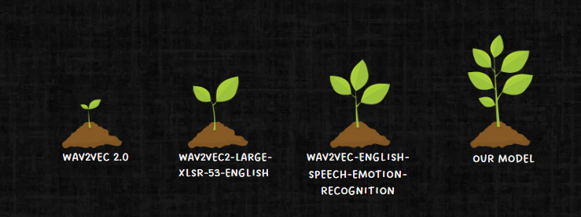

```python
Image(filename=HOME_DIR + 'images/Pretrained.PNG', width=1080)
```

```python
MAX_DURATION = 3 # Maximum duration of the input audio file we feed to our Wav2Vec 2.0 model.
SAMPLING_RATE = 16000 # Sampling rate is the number of samples of audio recorded every second
BATCH_SIZE = 8  # Batch-size for training and evaluating our model.
NUM_CLASSES = 6  # Number of classes our dataset.
HIDDEN_DIM = 768  # Dimension of our model output (768 in case of Wav2Vec 2.0 - Base).
MAX_SEQ_LENGTH = MAX_DURATION * SAMPLING_RATE  # Maximum length of the input audio file.
MAX_FRAMES = 263 # Wav2Vec 2.0 results in an output frequency with a stride of about 20ms.
MAX_EPOCHS = 2 # Maximum number of training epochs.

MODEL_CHECKPOINT = "r-f/wav2vec-english-speech-emotion-recognition"
```

```python
local_config_path = HOME_DIR + 'models/SER_PRETRAINED/config.json'
local_weights_path = HOME_DIR + 'models/SER_PRETRAINED/pytorch_model.bin'
local_preprocessor_config_path = HOME_DIR + 'models/SER_PRETRAINED/preprocessor_config.json'

config = Wav2Vec2Config.from_pretrained(local_config_path)

class Wav2Vec2ForSpeechClassification(nn.Module, PyTorchModelHubMixin):
    def __init__(self, config):
        super(Wav2Vec2ForSpeechClassification, self).__init__()
        self.wav2vec2 = Wav2Vec2Model(config)

        self.classifier = nn.ModuleDict({
            'dense': nn.Linear(config.hidden_size, config.hidden_size),
            'activation': nn.ReLU(),
            'dropout': nn.Dropout(config.final_dropout),
            'out_proj': nn.Linear(config.hidden_size, config.num_labels)
        })

    def forward(self, input_values):
        outputs = self.wav2vec2(input_values)
        hidden_states = outputs.last_hidden_state

        x = self.classifier['dense'](hidden_states[:, 0, :])
        x = self.classifier['activation'](x)
        x = self.classifier['dropout'](x)
        logits = self.classifier['out_proj'](x)

        return logits

wav2vec_model = Wav2Vec2ForSpeechClassification(config=config)
state_dict = torch.load(local_weights_path, map_location=torch.device('cpu'))
wav2vec_model.load_state_dict(state_dict, strict=True)

# Load the preprocessor configuration from the local file
with open(local_preprocessor_config_path, 'r') as file:
    preprocessor_config = json.load(file)

# Initialize the preprocessor using the loaded configuration
feature_extractor = Wav2Vec2FeatureExtractor(
    do_normalize=preprocessor_config["do_normalize"],
    feature_extractor_type=preprocessor_config["feature_extractor_type"],
    feature_size=preprocessor_config["feature_size"],
    padding_side=preprocessor_config["padding_side"],
    padding_value=preprocessor_config["padding_value"],
    processor_class_from_name=preprocessor_config["processor_class"],
    return_attention_mask=preprocessor_config["return_attention_mask"],
    sampling_rate=preprocessor_config["sampling_rate"]
)
```

**Table 5: Pre-trained Wav2Vec Model Summary**

[output not shown]

The evaluation of the pretrained model, `wav2vec-english-speech-emotion-recognition`, across various datasets yielded the following accuracies:

- For the RAVDESS and TESS datasets, the model achieved an accuracy of 97%.
- On the CREMA-D dataset, the model's performance dropped significantly, achieving an accuracy of 42%. This is not surprising as CREMA-D is introduced as a new dataset.
- When evaluated on the combined RAVDESS, TESS, and CREMA-D datasets, the model attained an accuracy of 63%.

**Table 6: Evaluation of Pre-trained Wav2Vec Model**

| Test Set | wav2vec-english-speech-emotion-recognition |
| --- | --- |
| RAVDESS, TESS | 97% |
| CREMA-D | 42% |
| RAVDESS, TESS, CREMA-D | 63% |

**Figure 5: Confusion Matrix on RAVDESS and TESS Test Sets using the Original Model**

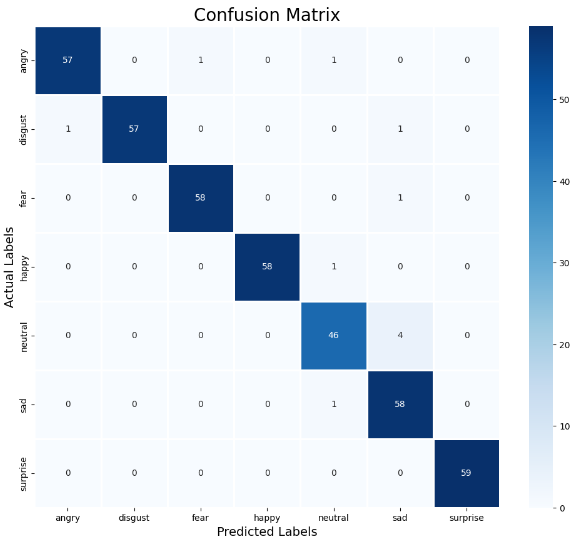

```python
display(Markdown('**Figure 5: Confusion Matrix on RAVDESS and TESS Test Sets using the Original Model**'))
Image(filename=HOME_DIR + 'images/Original Model - Test Set - RAVDESS_TESS.png', width=600)
```

**Figure 6: Confusion Matrix on CREMAD Test Sets using the Original Model**

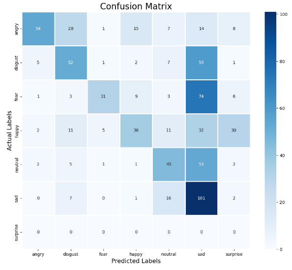

```python
display(Markdown('**Figure 6: Confusion Matrix on CREMAD Test Sets using the Original Model**'))
Image(filename=HOME_DIR + 'images/Original Model - Test Set - CREMAD.png', width=600)
```

**Figure 7: Confusion Matrix on RAVDESS, TESS, and CREMAD Test Sets using the Original Model**

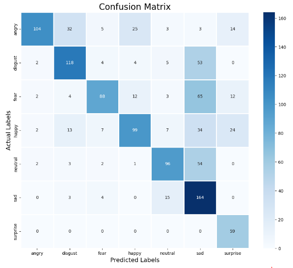

```python
display(Markdown('**Figure 7: Confusion Matrix on RAVDESS, TESS, and CREMAD Test Sets using the Original Model**'))
Image(filename=HOME_DIR + 'images/Original Model - Test Set - RAVDESS_TESS_CREMAD.png', width=600)
```

## TRAIN/TEST SPLIT

#### CLSTM Train Test Split

The dataset is split into training and testing sets for the CLSTM model. Initially, missing values in the feature data are filled with zeros to ensure consistency. The features (`X`) and labels (`Y`) are extracted from the `features_df` DataFrame. The labels are one-hot encoded to prepare them for classification.

- **Feature Extraction**: The input features are taken from all columns except the last, and the labels are extracted from the 'Emotions' column.
- **One-Hot Encoding**: The labels are transformed into a one-hot encoded format to facilitate multi-class classification.
- **Data Splitting**: The dataset is split into training and testing sets using an 80/20 ratio. The data is shuffled and split, with the `random_state` set for reproducibility.
- **Reshaping**: The training and testing data are reshaped to be suitable for LSTM input, with each sample being reshaped into a 3D tensor with one feature channel.

```
# Pad Audio
features_df=features_df.fillna(0)

# Train test split for CLSTM
X = features_df.iloc[: ,:-1].values
Y = features_df['Emotions'].values

# Encode Y
oe = OneHotEncoder()
Y = oe.fit_transform(np.array(Y).reshape(-1,1)).toarray()

x_train, x_test, y_train, y_test = train_test_split(X, Y, random_state=42,test_size=0.2, shuffle=True)

# Reshape for lstm
X_train = x_train.reshape(x_train.shape[0] , x_train.shape[1] , 1)
X_test = x_test.reshape(x_test.shape[0] , x_test.shape[1] , 1)
```

#### Wav2Vec Train/Test Split

The dataset is split into training and testing sets for the Wav2Vec model. Here, audio features are extracted and processed to prepare for training with the Wav2Vec model.

- **Feature Extraction**: The `feature_extractor` function processes audio data arrays into features suitable for input into the Wav2Vec model. It includes padding and truncation to standardize the length of audio samples.
- **Tensor Conversion**: The extracted features and labels are converted into PyTorch tensors and moved to the appropriate device (CPU/GPU) for model training.
- **Dataset Creation**: The `CustomDataset` class is defined to handle the input features and labels. This dataset class includes methods for retrieving data samples and their corresponding labels and lengths.
- **DataLoader Creation**: The `DataLoader` class is used to create data loaders for both training and evaluation datasets. These loaders handle batching, shuffling, and parallel data loading to optimize training efficiency.

```
# Define CustomDataset
class CustomDataset(Dataset):
    def __init__(self, inputs, labels, label_lengths):
        self.inputs = inputs
        self.labels = labels
        self.label_lengths = label_lengths

    def __len__(self):
        return len(self.inputs)

    def __getitem__(self, idx):
        return {
            'input_values': self.inputs[idx],
            'labels': self.labels[idx],
            'label_lengths': self.label_lengths[idx]
        }


# Example feature extraction (replace with actual feature extraction code)
train_inputs = feature_extractor(
    padded_audio_array_train_set_3, sampling_rate=16000, max_length=max_length_train_set_3,
    return_tensors='pt', padding=True, truncation=True
)
test_inputs = feature_extractor(
    padded_audio_array_test_set_3, sampling_rate=16000, max_length=max_length_test_set_3,
    return_tensors='pt', padding=True, truncation=True
)

# Convert feature extraction outputs to tensors and move to device
train_inputs = torch.tensor(train_inputs['input_values'], dtype=torch.float32).to(device)
train_labels = torch.tensor(raw_train_set_3.label, dtype=torch.long).to(device)
train_label_lengths = torch.tensor([1 for _ in train_labels], dtype=torch.long).to(device)

test_inputs = torch.tensor(test_inputs['input_values'], dtype=torch.float32).to(device)
test_labels = torch.tensor(raw_test_set_3.label, dtype=torch.long).to(device)
test_label_lengths = torch.tensor([1 for _ in test_labels], dtype=torch.long).to(device)

# Create datasets
train_dataset = CustomDataset(train_inputs, train_labels, train_label_lengths)
eval_dataset = CustomDataset(test_inputs, test_labels, test_label_lengths)

# Create DataLoader
train_loader = DataLoader(train_dataset, batch_size=16, shuffle=True, num_workers=0)
eval_loader = DataLoader(eval_dataset, batch_size=16, shuffle=False, num_workers=0)
```

# TRAINING (CLSTM)

```
num_epochs = 100
batch_size = 64

history = clstm_model.fit(
    X_train,
    y_train,
    epochs=num_epochs,
    batch_size=batch_size,
    validation_split=0.2,
    shuffle=True
)
```

**Figure 8: CLSTM: Training History**

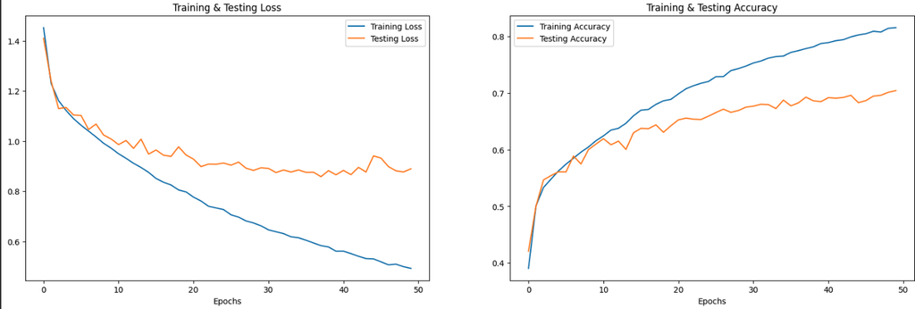

```python
display(Markdown('**Figure 8: CLSTM: Training History**'))
Image(filename=HOME_DIR + 'images/CLSTM.png', width=1080)
```

# FINETUNING (WAV2VEC)

The Wav2Vec finetuning process involves several key steps. First, the model is moved to a GPU if available to speed up computations. An AdamW optimizer with a learning rate of 2e-5 is used for parameter updates, and CrossEntropyLoss is employed to measure the model's performance.

In contrast, our finetuned model is trained on the three entire datasets, totalling almost 11,000 data points versus the original 4720 data points. Hence, we are increasing the train set in order to improve generalization.

```
# Move model to GPU if available
device = torch.device("cuda" if torch.cuda.is_available() else "cpu")
model.to(device)

torch.cuda.empty_cache()

# Initialize optimizer
optimizer = torch.optim.AdamW(model.parameters(), lr=2e-5)

# Define loss function
criterion = nn.CrossEntropyLoss()

# Define accuracy computation function
def compute_accuracy(predictions, labels):
    _, predicted = torch.max(predictions, 1)
    correct = (predicted == labels).sum().item()
    total = labels.size(0)
    return correct / total

# Training function
def train(model, data_loader, optimizer, device, accuracy_history):
    model.train()
    total_loss = 0
    correct_predictions = 0
    total_samples = 0

    for batch in tqdm(data_loader, desc="Training"):
        # Move data to the same device as the model
        input_values = batch['input_values'].to(device)
        labels = batch['labels'].to(device)

        optimizer.zero_grad()

        # Forward pass
        outputs = model(input_values=input_values)  # Assumes model returns logits
        loss = criterion(outputs, labels)

        # Backward pass and optimization
        loss.backward()
        optimizer.step()

        total_loss += loss.item()

        # Compute accuracy
        accuracy = compute_accuracy(outputs, labels)
        correct_predictions += (torch.max(outputs, 1)[1] == labels).sum().item()
        total_samples += labels.size(0)

    avg_loss = total_loss / len(data_loader)
    avg_accuracy = correct_predictions / total_samples
    accuracy_history.append(avg_accuracy)
    print(f"Training Loss: {avg_loss}, Accuracy: {avg_accuracy}")

# Evaluation function
def evaluate(model, data_loader, device, accuracy_history):
    model.eval()
    total_loss = 0
    correct_predictions = 0
    total_samples = 0

    with torch.no_grad():
        for batch in tqdm(data_loader, desc="Evaluating"):
            # Move data to the same device as the model
            input_values = batch['input_values'].to(device)
            labels = batch['labels'].to(device)

            # Forward pass
            outputs = model(input_values=input_values)  # Assumes model returns logits
            loss = criterion(outputs, labels)

            total_loss += loss.item()

            # Compute accuracy
            accuracy = compute_accuracy(outputs, labels)
            correct_predictions += (torch.max(outputs, 1)[1] == labels).sum().item()
            total_samples += labels.size(0)

    avg_loss = total_loss / len(data_loader)
    avg_accuracy = correct_predictions / total_samples
    accuracy_history.append(avg_accuracy)
    print(f"Evaluation Loss: {avg_loss}, Accuracy: {avg_accuracy}")

# Initialize accuracy history lists
train_accuracy_history = []
eval_accuracy_history = []

epochs = 3
# Training and evaluation loop
for epoch in range(epochs):  # Number of epochs
    print(f"Epoch {epoch + 1}")
    train(model, train_loader, optimizer, device, train_accuracy_history)
    evaluate(model, eval_loader, device, eval_accuracy_history)
```

**Figure 9: Pretrained Wav2Vec: Finetuning**

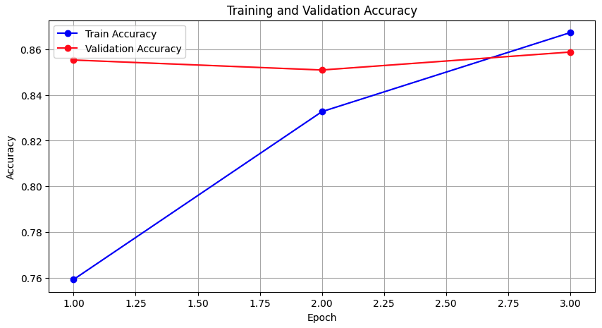

```python
display(Markdown('**Figure 9: Pretrained Wav2Vec: Finetuning**'))
Image(filename=HOME_DIR + 'images/Finetuning.png', width=800)
```

The Wav2Vec model, after finetuning, exhibited the following performance metrics:

- **Training Accuracy: 87%** The finetuned model achieved an accuracy of 87% on the training set. This reflects the model's improved ability to correctly classify training samples after the finetuning process.
- **Validation Accuracy: 86%** The model's accuracy on the validation set was 86%, which is close to the training accuracy. This high validation accuracy indicates that the finetuning process has enhanced the model's ability to generalize to unseen data, minimizing overfitting and demonstrating effective performance across both training and validation datasets.

# INFERENCE / DEMO APPLICATION

The demo application loads the trained model (model_finetuned.pth) and includes an audio component that records real-time audio. Every 10 seconds, the app samples the first 3 seconds of the audio, resamples it to 16,000 samples per second (as the model was trained on that rate), then extracts features using Wav2Vec2. The extracted features are then fed to the model for inference, where the logits that were produced by the model are passed through a softmax function to convert them into probabilities representing the likelihood of each emotion. These probabilities are mapped to corresponding emotion labels through a predefined mapping.

### app.py

```
import gradio as gr
import numpy as np
import matplotlib.pyplot as plt
from PIL import Image
import librosa
import time
from datetime import datetime
import pandas as pd
import torch
import torch.nn.functional as F
from tqdm import tqdm
from transformers import Wav2Vec2Config, Wav2Vec2Model
import torch.nn as nn
from huggingface_hub import PyTorchModelHubMixin, hf_hub_download
import json
from transformers import Wav2Vec2FeatureExtractor, Wav2Vec2Processor

# Define constants and paths
HOME_DIR = ""
local_config_path = 'config.json'
local_preprocessor_config_path = 'preprocessor_config.json'
local_weights_path = 'pytorch_model.bin'
local_training_args_path = 'training_args.bin'

# Define the id2label mapping
id2label = {
    0: "angry",
    1: "disgust",
    2: "fear",
    3: "happy",
    4: "neutral",
    5: "sad",
    6: "surprise"
}

# Define the prediction function
def predict(model, feature_extractor, data, max_length, id2label):
    # Extract features
    print(datetime.now().strftime('%Y-%m-%d%H:%M:%S'), ":Extracting features...")
    inputs = feature_extractor(data,
                               sampling_rate=16000,
                               max_length=max_length,
                               return_tensors='tf',
                               padding=True,
                               truncation=True)
    torch_inputs = torch.tensor(inputs['input_values'].numpy(), dtype=torch.float32)

    print(datetime.now().strftime('%Y-%m-%d%H:%M:%S'), ":Predicting...")
    # Forward pass
    outputs = model(input_values=torch_inputs)

    # Extract logits from the output
    logits = outputs

    # Apply softmax to get probabilities
    probabilities = F.softmax(logits, dim=-1)

    # Get the predicted class index
    predicted_class_idx = torch.argmax(probabilities, dim=-1).item()
    predicted_label = id2label[predicted_class_idx]

    return predicted_label, probabilities

# Define the Wav2Vec2 model class
class Wav2Vec2ForSpeechClassification(nn.Module, PyTorchModelHubMixin):
    def __init__(self, config):
        super(Wav2Vec2ForSpeechClassification, self).__init__()
        self.wav2vec2 = Wav2Vec2Model(config)

        self.classifier = nn.ModuleDict({
            'dense': nn.Linear(config.hidden_size, config.hidden_size),
            'activation': nn.ReLU(),
            'dropout': nn.Dropout(config.final_dropout),
            'out_proj': nn.Linear(config.hidden_size, config.num_labels)
        })

    def forward(self, input_values):
        outputs = self.wav2vec2(input_values)
        hidden_states = outputs.last_hidden_state

        x = self.classifier['dense'](hidden_states[:, 0, :])
        x = self.classifier['activation'](x)
        x = self.classifier['dropout'](x)
        logits = self.classifier['out_proj'](x)

        return logits

# Load the preprocessor configuration
with open(local_preprocessor_config_path, 'r') as file:
    preprocessor_config = json.load(file)

# Initialize the preprocessor
feature_extractor = Wav2Vec2FeatureExtractor(
    do_normalize=preprocessor_config["do_normalize"],
    feature_extractor_type=preprocessor_config["feature_extractor_type"],
    feature_size=preprocessor_config["feature_size"],
    padding_side=preprocessor_config["padding_side"],
    padding_value=preprocessor_config["padding_value"],
    processor_class_from_name=preprocessor_config["processor_class"],
    return_attention_mask=preprocessor_config["return_attention_mask"],
    sampling_rate=preprocessor_config["sampling_rate"]
)

# Load the finetuned model from Huggingface Hub
model_path = hf_hub_download(
    repo_id="kvilla/wav2vec-english-speech-emotion-recognition-finetuned",
    filename="model_finetuned.pth"
)

# Load the model
saved_model = torch.load(model_path, map_location=torch.device('cpu'))

# Create and initialize the model
config = Wav2Vec2Config.from_pretrained(local_config_path)
model = Wav2Vec2ForSpeechClassification(config=config)
model.load_state_dict(saved_model)
model.eval()

print("Model initialized successfully.")

# Define the emotion recognition function
def recognize_emotion(audio):
    # Load the audio file using librosa
    sample_rate, audio_data = audio

    # Ensure audio data is in floating-point format
    if not np.issubdtype(audio_data.dtype, np.floating):
        audio_data = audio_data.astype(np.float32)

    # Resample if necessary
    if sample_rate != 16000:
        print(datetime.now().strftime('%Y-%m-%d%H:%M:%S'), ":Resampling audio...")
        audio_data = librosa.resample(audio_data,
                                      orig_sr=sample_rate,
                                      target_sr=16000)

    # Predict the emotion
    emotion, probabilities = predict(model,
                                     feature_extractor,
                                     audio_data,
                                     48000, # Limit to 3s 16000 samples x 3
                                     id2label)

    print(probabilities)
    probs = probabilities.detach().numpy().flatten().tolist()

    # Convert probabilities to percentages
    percentages = [round(prob * 100, 2) for prob in probs]

    # Define the class labels
    labels = ["angry", "disgust", "fear", "happy", "neutral", "sad", "surprise"]

    # Create a DataFrame
    df = pd.DataFrame({"Emotion": labels, "Probability (%)": percentages})
    df = df.sort_values(by="Probability (%)", ascending=False)

    print(datetime.now().strftime('%Y-%m-%d%H:%M:%S'), df)

    return emotion, get_emotion_image(emotion), df

# Define the function to get the emotion image
def get_emotion_image(emotion):
    emotion_to_image = {
        "angry": "angry.jpeg",
        "disgust": "disgust.jpeg",
        "fear": "fear.jpeg",
        "happy": "happy.jpeg",
        "neutral": "neutral.jpeg",
        "sad": "sad.jpeg",
        "surprise": "surprise.jpeg"
    }

    image_path = emotion_to_image.get(emotion, "default.jpg")
    return Image.open(image_path)

# Create Gradio interface
demo = gr.Blocks()
with demo:
    df_logs = pd.DataFrame(columns=['Timestamp', 'Emotion'])
    theme = gr.themes.Soft(),
    audio_input = gr.Audio(type="numpy",
                            sources=["microphone"],
                            show_label=True,
                            streaming=True
                            )
    text_output = gr.Textbox(label="Recognized Emotion")
    output_df = gr.DataFrame(label="Emotion Probabilities")
    image_output = gr.Image(label="Emotion Image", scale = 1, interactive = False)
    df_logs = gr.DataFrame(label="Output Logs", headers = ['Timestamp', 'Emotion'])

    # Define the process function
    def process_audio(audio, emotion, image, state, df_probs, df_logs):
        current_time = time.time()
        if state is None or (current_time - state >= 10):
            state = current_time
            emotion, image, df_probs = recognize_emotion(audio)

            timestamp = datetime.now().strftime('%Y-%m-%d %H:%M:%S')
            new_row = {'Timestamp': timestamp, 'Emotion': emotion}

            df_logs = pd.concat([df_logs, pd.DataFrame([new_row])], ignore_index=True)
            print(datetime.now().strftime('%Y-%m-%d%H:%M:%S'), "Predicted emotion: ", emotion)

            return emotion, image, state, df_probs, df_logs
        else:
            print(datetime.now().strftime('%Y-%m-%d%H:%M:%S'), "Not yet time")
            return emotion, image, state, df_probs, df_logs

    state = gr.State(None)
    audio_input.stream(fn=process_audio, inputs=[audio_input,
                                                 text_output,
                                                 image_output,
                                                 state,
                                                 output_df,
                                                 df_logs],
                       outputs=[text_output,
                                image_output,
                                state,
                                output_df,
                                df_logs])

# Launch Gradio demo
demo.launch(share=True)
```

The Gradio interface in this application serves as an intuitive and user-friendly platform for real-time emotion recognition based on audio input. The interface is built using gr.Blocks, which allows for the flexible arrangement of components like audio inputs, text outputs, dataframes, and images. The audio_input component captures live audio from the user’s microphone, while the text_output, output_df, and image_output components are designed to display the recognized emotion, the corresponding probabilities for each emotion, and an image representing the predicted emotion, respectively.

[figure not shown]

```python
Image(filename=HOME_DIR + 'images/demo_app.jpg', width=1080)
```

The interface is built using gr.Blocks, which allows for the flexible arrangement of components like audio inputs, text outputs, dataframes, and images. The audio_input component captures live audio from the user’s microphone, while the text_output, output_df, and image_output components are designed to display the recognized emotion, the corresponding probabilities for each emotion, and an image representing the predicted emotion, respectively.

The interface is designed to stream the audio input and automatically trigger the emotion recognition process every 10 seconds. This is managed through a process_audio function that handles the logic for when to sample the audio, perform inference using the loaded Wav2Vec2 model, and update the output components with the prediction results. A key feature of this Gradio interface is the logging functionality, where each emotion prediction is timestamped and stored in a log, providing a record of the inferences made during the session. This setup leverages Gradio’s capabilities to create an interactive and engaging experience for users, allowing them to easily test and observe the model’s predictions in real-time.

The demo application was then deployed on Hugging Face Spaces, allowing users to test and interact with the application directly.

# CONCLUSION

The evaluation of the pretrained model, `wav2vec-english-speech-emotion-recognition`, and our finetuned model across various datasets yielded the following accuracies:

- For the RAVDESS and TESS datasets, our model achieved an accuracy of 99%, slightly outperforming the pretrained model, which achieved 97%.
- On the CREMA-D dataset, the pretrained model showed a significant drop in performance with an accuracy of 42%, whereas our model performed substantially better, achieving 85%.
- When evaluated on the combined RAVDESS, TESS, and CREMA-D datasets, our model attained an accuracy of 86%, surpassing the pretrained model’s accuracy of 63%.

**Table 7: Evaluation of Pre-trained Wav2Vec Model vs. Finetuned Model**

| Test Set | wav2vec-english-speech-emotion-recognition | Finetuned Model |
| --- | --- | --- |
| RAVDESS, TESS | 97% | 99% |
| CREMA-D | 42% | 85% |
| RAVDESS, TESS, CREMA-D | 63% | 86% |

*Note: The test sets used for evaluating the model were not part of the training process. They were exclusively reserved for assessing the model’s performance, ensuring an unbiased evaluation of its ability to generalize to new, unseen data.*

**Figure 8: Confusion Matrix on RAVDESS and TESS Test Sets using the Finetuned Model**

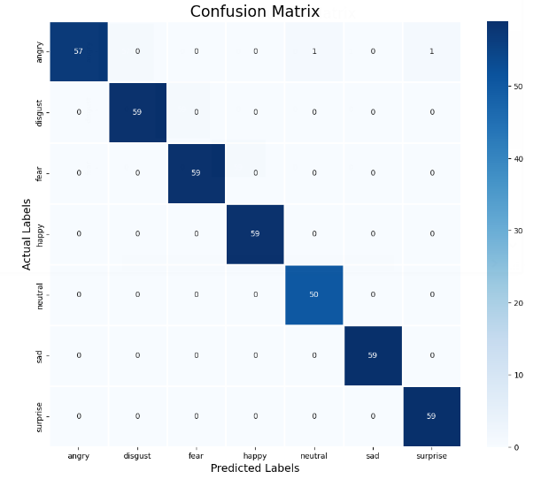

```python
display(Markdown('**Figure 8: Confusion Matrix on RAVDESS and TESS Test Sets using the Finetuned Model**'))
Image(filename=HOME_DIR + 'images/Our Model - Test Set - RAVDESS_TESS.png', width=600)
```

**Figure 9: Confusion Matrix on RAVDESS, TESS, and CREMAD Test Sets using the Finetuned Model**

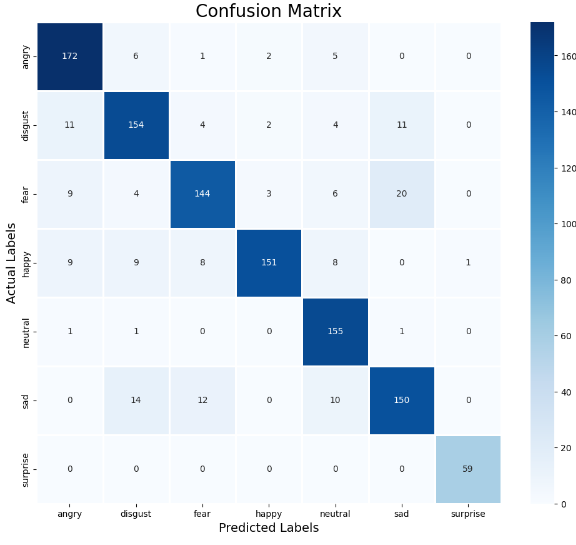

```python
display(Markdown('**Figure 9: Confusion Matrix on RAVDESS, TESS, and CREMAD Test Sets using the Finetuned Model**'))
Image(filename=HOME_DIR + 'images/Our Model - Test Set - RAVDESS_TESS_CREMAD.png', width=600)
```

# RECOMMENDATION

1. **Enhance the Dataset / Use Case: Multilingual Customer Support, Cross-Cultural Research**
   - *Non-American Actors*: Including audio from actors with various accents and dialects will enhance the model’s ability to understand and accurately interpret emotions in global customer interactions. This is particularly important for customer support systems deployed in diverse regions where users might speak with different accents.
   - *Varied Accents and Dialects*: In studies involving cross-cultural research, having a dataset with diverse speech patterns ensures that emotional analyses are culturally sensitive and accurate. This is crucial for research aimed at understanding emotional expression across different cultures.
2. **Adopt a Multi-Modal Approach / Use Case: Interactive Virtual Assistants, Therapy and Counseling**
   - *Facial Expressions*: For virtual assistants or chatbots, integrating facial expression analysis can improve the system’s ability to respond appropriately to users' emotional states. For instance, an assistant that recognizes when a user is frustrated or happy based on both voice and facial cues can tailor responses more effectively.
   - *Contextual Information*: In therapeutic applications, combining audio with visual and contextual data can provide a more holistic understanding of a client's emotional state. This integration helps therapists better gauge emotions during sessions, leading to more personalized and effective interventions.

To enhance model performance, various strategies can be implemented.

- **Improving Data Augmentation** is crucial, particularly for real-world audio processing where **noise injection** ensures accuracy in noisy environments like smart home devices and mobile apps.
- Additionally, **time shifting and pitch modulation** can make voice-controlled systems more robust to different speaking styles.
- **Regularization Techniques** such as **dropout** are beneficial for personalized emotion detection systems, preventing overfitting and ensuring broader generalization. Data augmentation also helps models that need to recognize emotions across diverse user bases.
- **Hyperparameter Tuning** plays a role in optimizing performance for dynamic customer interactions, with adjustments in **learning rate and batch size** improving real-time systems, while tuning the **number of epochs** balances training time with model accuracy for rapid updates.
- Evaluating **additional metrics** like **precision, recall, and F1-score** is valuable for emotion-sensitive marketing and advanced sentiment analysis, enhancing model targeting and accuracy.
- Lastly, **user feedback integration** through **active learning** ensures that adaptive learning systems remain relevant and accurate by evolving with user interactions.

By adopting these strategies, the model's capabilities can be expanded and refined, leading to better performance and utility across various applications. Continuous improvement through these methods will enhance the model’s ability to understand and respond to diverse emotional cues, thereby increasing its value and effectiveness in practical deployments.

# SOURCES

1. https://engineering.jhu.edu/nsa/research/emotional-speech/#:~:text=Emotional%20cues%20in%20speech%20are,of%20which%20impact%20emotion%20perception
2. https://zenodo.org/records/1188976#.YFZuJ0j7SL8
3. https://datasets.activeloop.ai/docs/ml/datasets/ravdess-dataset/
4. https://www.kaggle.com/datasets/uwrfkaggler/ravdess-emotional-speech-audio/data
5. https://tspace.library.utoronto.ca/handle/1807/24487
6. https://www.kaggle.com/datasets/ejlok1/cremad
7. https://www.researchgate.net/publication/365912955_Multi-feature_stacking_order_impact_on_speech_emotion_recognition_performance
8. https://www.researchgate.net/figure/Best-feature-order-for-a-specific-emotion_tbl3_365912955
9. https://www.kaggle.com/code/mostafaabdlhamed/speech-emotion-recognition-97-25-accuracy#CLSTM-Model
10. https://huggingface.co/
11. https://huggingface.co/r-f/wav2vec-english-speech-emotion-recognition
12. https://www.linkedin.com/pulse/open-source-vs-usecase-specific-models-why-tailored-solutions-speech/
13. https://www.projectpro.io/article/speech-emotion-recognition-project-using-machine-learning/573
14. https://ijritcc.org/index.php/ijritcc/article/view/8472/6636